# Example Analysis

Matt

1/31/2019

This example is taken from https://crumplab.github.io/statisticsLab/lab-10-factorial-anova.html#r-10. The data file is `stroop_stand.csv`, and can be found here https://github.com/CrumpLab/statisticsLab/tree/master/data

## Load the data and libraries you will use

```r
library(data.table)
library(dplyr)
library(ggplot2)
all_data <- fread("data/stroop_stand.csv")
```

## Pre-processing

Pre-processing can include many steps. Here, we convert the data from wide to long format, and make a new data frame.

```r
RTs <- c(as.numeric(unlist(all_data[,1])),
         as.numeric(unlist(all_data[,2])),
         as.numeric(unlist(all_data[,3])),
         as.numeric(unlist(all_data[,4]))
         )

Congruency <- rep(rep(c("Congruent","Incongruent"),each=50),2)
Posture <- rep(c("Stand","Sit"),each=100)
Subject <- rep(1:50,4)

stroop_df <- data.frame(Subject,Congruency,Posture,RTs)
```

### Checks

It is important to check the data you are analyzing before you analyze. The checks you make depend on the questions you are trying to answer. Here we check the number of subjects in each condition.

This is a 2x2 repeated measures design, each subject should have 4 means

```r
num_subjects <- stroop_df %>%
                  group_by(Subject) %>%
                  summarise(counts = length(Subject))
total_subjects <- length(num_subjects$Subject)
total_has_four <- num_subjects$counts == 4
sum(total_has_four) == total_subjects
```

```
## [1] TRUE
```

Are there any subjects with huge mean RTs? Could indicate something weird happened.

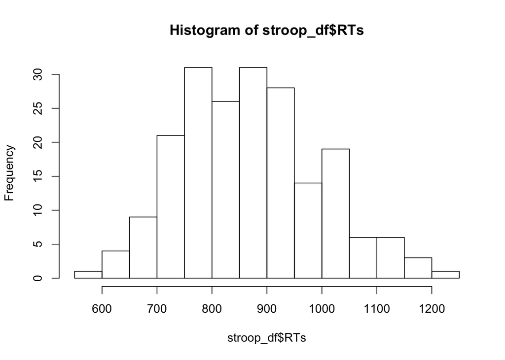

```r
hist(stroop_df$RTs)
```

### Exclusion

If you are going to exlcude subjects from analysis, then justify your exclusion criterion, and then eliminate subject data from the data frame. We will not exlcude any subjects here.

```r
# no exclusions
```

## Analysis

Now you can begin analysis. This experiment asked whether the Stroop effect (difference between mean incongruent and mean congruent), depends on whether people are sitting or standing. Let’s get the means, make a tbale, then plot the data.

### table of 2x2 means

```r
overall_means <- stroop_df %>%
                  group_by(Posture,Congruency) %>%
                  summarise(meanRT = mean(RTs),
                            SEMRT = (sd(RTs)/sqrt(length(RTs))))

# make a table of overall means
knitr::kable(overall_means)
```

| Posture | Congruency | meanRT | SEMRT |
| --- | --- | --- | --- |
| Sit | Congruent | 821.9232 | 16.60384 |
| Sit | Incongruent | 940.7855 | 17.91041 |
| Stand | Congruent | 807.9599 | 14.93521 |
| Stand | Incongruent | 903.9131 | 15.34939 |

### plot of 2x2 means

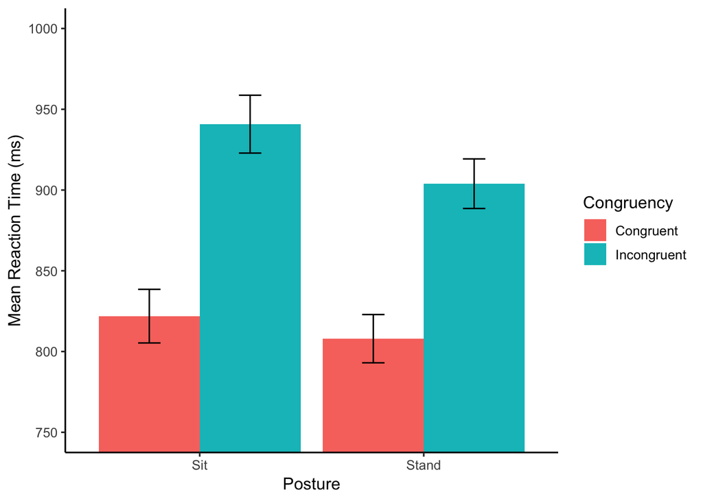

```r
ggplot(overall_means, aes(x=Posture,
                          y=meanRT,
                          group=Congruency,
                          fill=Congruency))+
  geom_bar(stat="identity",position="dodge")+
  theme_classic(base_size=12)+
  ylab("Mean Reaction Time (ms)")+
  geom_errorbar(aes(ymin=meanRT-SEMRT,
                    ymax=meanRT+SEMRT),
                position=position_dodge(width=0.9),
                width=.2,
                color="black")+
  coord_cartesian(ylim=c(750,1000))
```

### Repeated measure ANOVA

```r
# Make sure Subjecdt is  a factor
stroop_df$Subject <-  as.factor(stroop_df$Subject)

aov_out <- aov(RTs~Posture*Congruency + Error(Subject/(Posture*Congruency)), stroop_df)
#print summary of ANOVA table
summary(aov_out)
```

```
##
## Error: Subject
##           Df  Sum Sq Mean Sq F value Pr(>F)
## Residuals 49 2250739   45933
##
## Error: Subject:Posture
##           Df Sum Sq Mean Sq F value  Pr(>F)
## Posture    1  32303   32303    7.33 0.00931 **
## Residuals 49 215948    4407
## ---
## Signif. codes:  0 '***' 0.001 '**' 0.01 '*' 0.05 '.' 0.1 ' ' 1
##
## Error: Subject:Congruency
##            Df Sum Sq Mean Sq F value Pr(>F)
## Congruency  1 576822  576822   342.5 <2e-16 ***
## Residuals  49  82535    1684
## ---
## Signif. codes:  0 '***' 0.001 '**' 0.01 '*' 0.05 '.' 0.1 ' ' 1
##
## Error: Subject:Posture:Congruency
##                    Df Sum Sq Mean Sq F value  Pr(>F)
## Posture:Congruency  1   6560    6560   8.964 0.00431 **
## Residuals          49  35859     732
## ---
## Signif. codes:  0 '***' 0.001 '**' 0.01 '*' 0.05 '.' 0.1 ' ' 1
```

```r
# prints a nicer ANOVA table
summary_out <- summary(aov_out)
library(xtable)
knitr::kable(xtable(summary_out))
```

|  | Df | Sum Sq | Mean Sq | F value | Pr(>F) |
| --- | --- | --- | --- | --- | --- |
| Residuals | 49 | 2250738.636 | 45933.4416 | NA | NA |
| Posture | 1 | 32303.453 | 32303.4534 | 7.329876 | 0.0093104 |
| Residuals1 | 49 | 215947.614 | 4407.0942 | NA | NA |
| Congruency | 1 | 576821.635 | 576821.6349 | 342.452244 | 0.0000000 |
| Residuals | 49 | 82534.895 | 1684.3856 | NA | NA |
| Posture:Congruency | 1 | 6560.339 | 6560.3389 | 8.964444 | 0.0043060 |
| Residuals | 49 | 35859.069 | 731.8177 | NA | NA |

```r
# prints means for each effect
print(model.tables(aov_out,"means"), format="markdown")
```

```
## Tables of means
## Grand mean
##
## 868.6454
##
##  Posture
## Posture
##   Sit Stand
## 881.4 855.9
##
##  Congruency
## Congruency
##   Congruent Incongruent
##       814.9       922.3
##
##  Posture:Congruency
##        Congruency
## Posture Congruent Incongruent
##   Sit   821.9     940.8
##   Stand 808.0     903.9
```

### Example Write-Up

We submitted the mean reaction times for each subject in each condition to a 2 (Congruency: congruecnt vs. incongruent) x 2 (Posture: Standing vs. Sitting) repeated measures ANOVA.

There was a main effect of Congruency, F (1, 49) = 342.45, MSE = 1684.39, p < 0.001. Mean reaction times were slower for incongruent (922 ms) than congruent groups (815 ms).

There main effect of Posture was significant, F (1, 49) = 7.33, MSE = 4407.09, p =.009. Mean reaction times were slower for sitting (881 ms) than standing groups (855 ms).